# Problem Set 5

Ian McGroarty

01MAR2020

## Problem 1

Apply Inverse Transform Method to Laplace distribution

$$\begin{align*}
f(x) &= \frac{\lambda}{2}e^{-\lambda |x - \theta} \\
&= e^{-2|x-2} && (\lambda =2, \theta = 2) \\
& \text{Break into cases for absolute} \\
f(x) &= e^{-2(x-2)} && x>2 \\
f(x) &= e^{2(x-2)} && x<2 \\
& \text{Integrate to find F(x)} \\
f(x) &= 1-\frac{1}{2} \cdot e^{-2x+4)} && x>2 \\
f(x) &= \frac{1}{2} \cdot e^{2x-4)} && x<2 \\
& \text{Inverte by setting = to U} \\
x &= -\frac{1}{2}[log(-2u+2)-4] \\
x &= \frac{1}{2}[log(2u)+4] \\
\end{align*}$$

We see that the two values of X are equally likely so we integrate from 0 to 0.5 and 0.5 to 1 over U. This is demonstrated with R code below. I’ve also compared the derived distribution to the Laplace distribution generated by the R function *rlaplace* in package *rmutil*

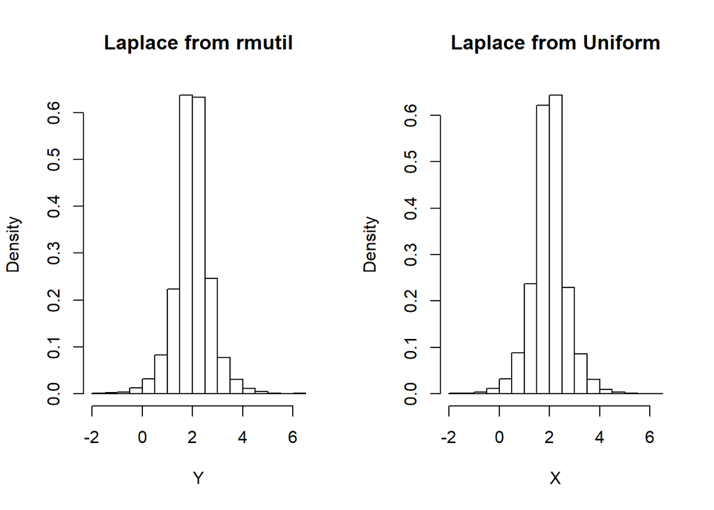

```r
Nsim <- 10^4
U <- runif(Nsim , min=0,max=1)

## From the actual Lapace distribution through rmutil package
  # m = theta = 2 & s = 1/lambda = (1/2)
Y <- rlaplace(Nsim, m=2,s=(1/2))

## Generate from the inverse transform method
X <- ifelse(U>.5,(log(-2*(U) + 2)-4)/(-2),
     ifelse(U<.5,(log(2*U)+4)/(2),2))
par(mfrow = c(1,2))
hist(Y,freq=F, main= "Laplace from rmutil")
hist(X,freq=F, main= "Laplace from Uniform")
```

## Problem 2

Let Randomn variable X has pdf:
$$f(x) = \left\{
\begin{align*}
(1/4) && 0 < x < 1 \\
x-(3/4) && 1 \leq x \leq 2
\end{align*}
\right.$$
### (a) Gen a r.v. using inverse transform method 1. First we integrate to find F(x)
$$\begin{align*}
0<x<1 &&F(x) =& \int_{\infty}^x \\
&& =& \int_{\infty}^0 dt + \int_0^x \frac{1}{4} \\
&& =& \frac{t}{4}|_0^x \\
&& =& \frac{x}{4} \\
1 \leq x \leq 2 && F(X)=& \int_{\infty}^x \\
&& =& \int_{\infty}^0 dt + \int_0^1 \frac{1}{4}dt + \int_1^x(t-(3/4)dt) \\
&& =& \frac{1}{4} + [\frac{1}{2}t^2 - \frac{3}{4}t]_1^x \\
&& =& \frac{1}{4} + [\frac{1}{2}x^2 - \frac{3}{4}x]-[\frac{1}{2}-\frac{3}{4}] \\
&& =& \frac{1}{2}x^2 - \frac{3}{4}x + \frac{1}{2}
\end{align*}$$
$$F(x) = \left\{
\begin{align*}
\frac{1}{4}x && 0 < x < 1 \\
\frac{1}{2}x^2 - \frac{3}{4}x + \frac{1}{2} && 1 \leq x \leq 2
\end{align*}
\right.$$
2. Find $F^-(x)$ by setting equal to U and solving for x:
$$\begin{align*}
U &= \frac{1}{4} &\implies x &= 4U|_0^{0.25} \\
U &= \frac{1}{2}x^2 - \frac{3}{4}x + \frac{1}{2} &\implies x&= \frac{1}{4}(3 \mp \sqrt{32U - 7}|_{0.25}^1)
\end{align*}$$

3. Using R and a uniform distribution from 0,1 with each x having equal probability for U: (R code and plot provided at the end of the problem). See that the histogram follows the line generated from plotting f(x) very well.

### (b) Gen a r.v. using the accept reject method

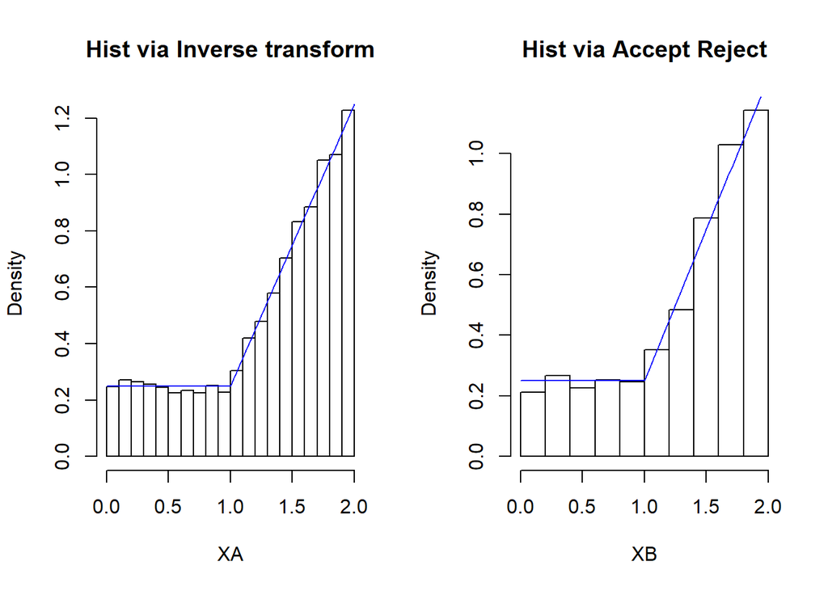

```r
## PART (a) USING THE INVERSE TRANSFORM METHOD
# Set the number of simulations
  Nsim <- 10^4
# Generate the uniform values to plug into the inverse
  U <- runif(Nsim , min=0,max=1)
# Evaluate the inverse for the Us
  XA <- ifelse(U<(1/4),4*U,ifelse(U>(1/4),(1/4)*(3 + sqrt(32*U -7)),NA))


## PART (b) USING ACCEPT REJECT
# Set the max
  M <- (2)
# Set the function
  fx <- function(x){
    ifelse((x<1),(1/4),ifelse((1<=x & x<= 2),x-(3/4),NA))
  }
# Generate x candidates over the range under condiseration
  Xcand <- runif(Nsim,min=0,max=2)
# Generate y candidates up to M
  Ycand <- runif(Nsim, min=0, max=M)
# Keep the x candidates for which the Y candidates are viable solutions
  XB <- Xcand[Ycand < fx(Xcand)]

## Plots for (a) and (b)
par(mfrow = c(1,2))
hist(XA,freq=F,main="Hist via Inverse transform")
plot(fx,xlim=c(0,2.5),ylim=c(0,2.5),col = "blue",add=TRUE)
hist(XB,freq=F,main="Hist via Accept Reject")
plot(fx,xlim=c(0,2.5),ylim=c(0,2.5),col = "blue",add=TRUE)
```

## Problem 3

Let Randomn variable X has pdf:
$$f(x) = \left\{
\begin{align*}
(1/2)x && 0 < x < 1 \\
(1/2) && 1 \leq x \leq \frac{5}{2}
\end{align*}
\right.$$

1. First we integrate to find F(x)
   $$\begin{align*}
   0<x<1 &&F(x) =& \int_{\infty}^x \\
   && =& \int_{\infty}^0 dt + \int_0^x \frac{x}{2} \\
   && =& \frac{x^2}{4}|_0^x \\
   && =& \frac{x^2}{4} \\
   1 \leq x \leq 2 && F(X)=& \int_{\infty}^x \\
   && =& \int_{\infty}^0 dt + \int_0^1 \frac{x}{2}dt + \int_1^x \frac{1}{2} dt) \\
   && =& \frac{1}{4} + \frac{t}{2}|_1^x \\
   && =& \frac{1}{2} + \frac{x}{2} - \frac{1}{2} \\
   && =& \frac{x}{2} - \frac{1}{4} \\
   \end{align*}$$
   $$F(x) = \left\{
   \begin{align*}
   \frac{1}{4}x^2 && 0 < x < 1 \\
   \frac{1}{2}x - \frac{1}{4} && 1 \leq x \leq \frac{5}{2}
   \end{align*}
   \right.$$
2. Find $F^-(x)$ by setting equal to U and solving for x:
   $$\begin{align*}
   U &= \frac{1}{4}x^2 &\implies x &= \sqrt{4U}|_0^{0.25} \\
   U &= \frac{1}{2}x - \frac{1}{4} &\implies x &= 2U + \frac{1}{2}_{0.25}^1
   \end{align*}$$
3. Using R and a uniform distribution from 0,1 with each x having equal probability for U: (R code and plot provided at the end of the problem). See that the histogram follows the line generated from plotting f(x) very well.

### (b) Gen a r.v. using the accept reject method

$$sup(f(x)) = (1/2)|x=1 \implies x_{opt} = \frac{16}{25} \rightarrow M = \frac{f(1/2)}{g(1/2)}$$

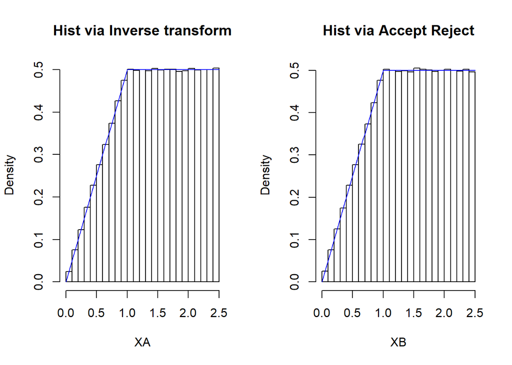

```r
## PART (a) USING THE INVERSE TRANSFORM METHOD
# Set the number of simulations
  Nsim <- 10^6
# Generate the uniform values to plug into the inverse
  U <- runif(Nsim , min=0,max=(1))
# Evaluate the inverse for the Us
  XA <- ifelse(U<(1/4),sqrt(4*U),ifelse(U>(1/4),2*U+(1/2),NA))


## PART (b) USING ACCEPT REJECT
# Set the max
  M <- ((1/2))
# Set the function
  fx <- function(x){
    ifelse((x<1),(x/2),ifelse((1<=x & x<= 2.5),(1/2),NA))
  }
# Generate x candidates over the range under condiseration
  Xcand <- runif(Nsim,min=0,max=2.5)
# Generate y candidates up to M
  Ycand <- runif(Nsim, min=0, max=M)
# Keep the x candidates for which the Y candidates are viable solutions
  XB <- Xcand[Ycand < fx(Xcand)]

## Plots for (a) and (b)
par(mfrow = c(1,2))
hist(XA,freq=F,main="Hist via Inverse transform")
plot(fx,xlim=c(0,2.5),ylim=c(0,2.5),col = "blue",add=TRUE)
hist(XB,freq=F,main="Hist via Accept Reject")
plot(fx,xlim=c(0,2.5),ylim=c(0,2.5),col = "blue",add=TRUE)
```

## Problem 4

Apply the inverse-transform method to generate a random variable from the discrete uniform distribution with pdf
$$f(x) = \left\{
\begin{align*}
\frac{1}{n+1} && x=0,1...n \\
0 && \text{otherwise}
\end{align*}
\right.$$

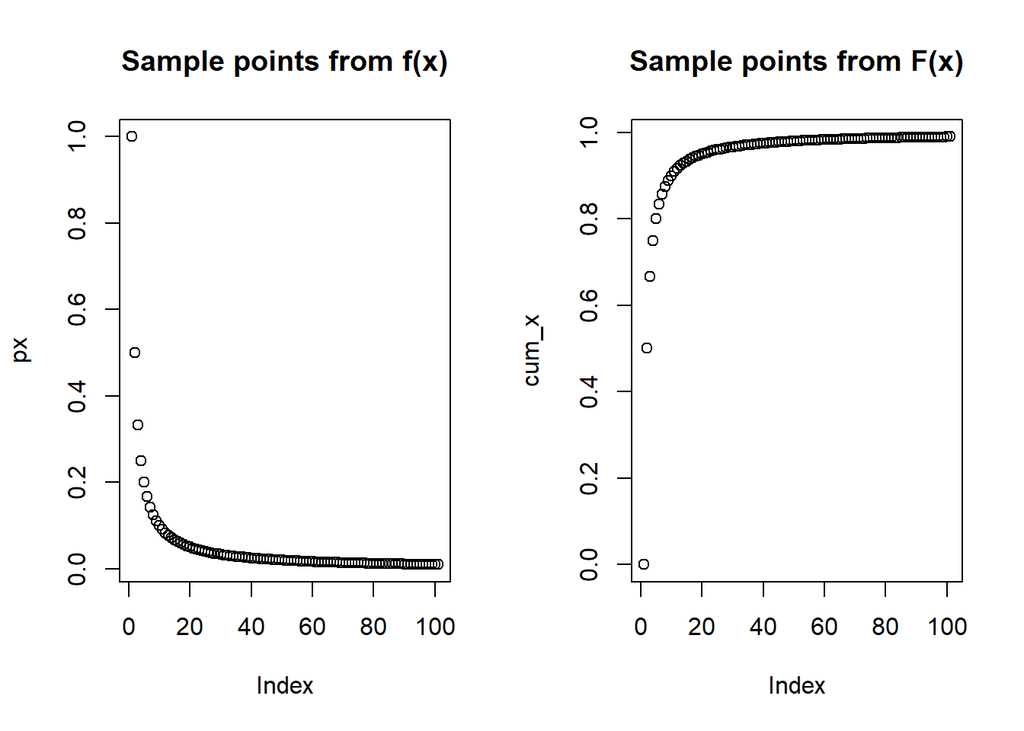

```r
n <- seq(0,100)
px <- (1/(n+1))
cum_x <- (n/(n+1))
par(mfrow = c(1,2))
plot(px,main = "Sample points from f(x)")
plot(cum_x, main= "Sample points from F(x)")
```

```r
U <- runif(100,min=0,max=1)
x <- U*(n+1)
```

[figure not shown]

```r
hist(x,freq=F,breaks=seq(0,100,5))
```